# Predictive Model for Mines Park Fault

### Methods:

To begin, we loaded in the data and found the exact date where the fault happened. We then used a linear regression model and then a backwards step regression to find the coefficients of all the variables that were most correlated to the pH. Then we split the variables into control and response variables so we could compare them to the pH. After this, we split the variables of the data into a control and response variable set. We used these sets to further look at different formulas and how much they correlated with the pH. We did this by splitting the data into smaller portions to make it more workable since there are over 40,000 observations. For both the control and response variables we used to the pairs function to make a scatter plot of the variables against the pH to see if the pH was strongly correlated with any other variable, plotted the variables against time to see if there was a trend in the graph right before the fault (figures 2 and 2), made a linear model and performed a backwards regression to see which variables were correlated the most with the pH, and performed a lasso fit to see if it had a better r-squared than the previous liner model.

###### Figure 2:

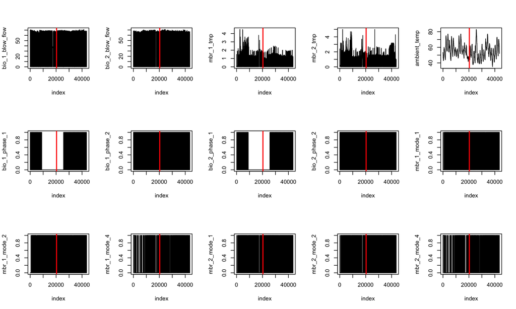

###### Figure 3:

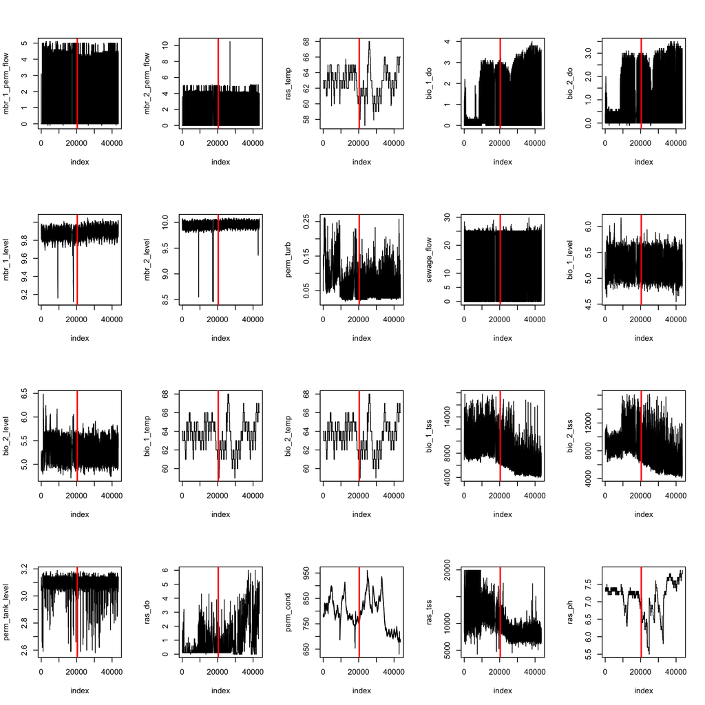